# Part II - Ford GoBike System Data Exploration and Visualization

## by Wejdan Al-Qahtani

## Investigation Overview

#### *In the San Francisco Bay Area of California, Ford GoBike is a regional public bicycle sharing scheme. Bay Area Bike Share, a pilot program for the region, started in August 2013 with 700 bikes and 70 stations dispersed around San Francisco and San Jose. The Ford GoBike system presently has more than 2,600 bicycles spread out among 262 stations in San Francisco, the East Bay, and San Jose. On June 28, 2017, the program was formally unveiled as Ford GoBike in collaboration with Ford Motor Company.*

#### *The Ford GoBike bike share program uses a fleet of strong, well-made bikes that are locked into a system of docking stations spread out over the city. The bike is perfect for one-way travels because you may unlock it at one station and return it to any other station in the network. Additionally, the bikes are always ready for use, and anyone can use any bike in the network provided they join or buy a pass.*

## Dataset Overview

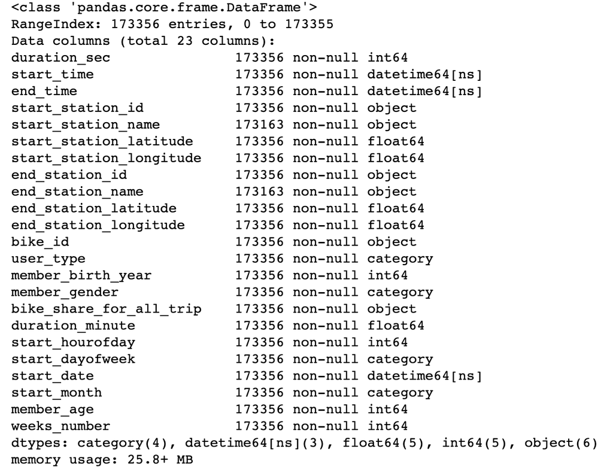

## User Types and Their Weekly Usage

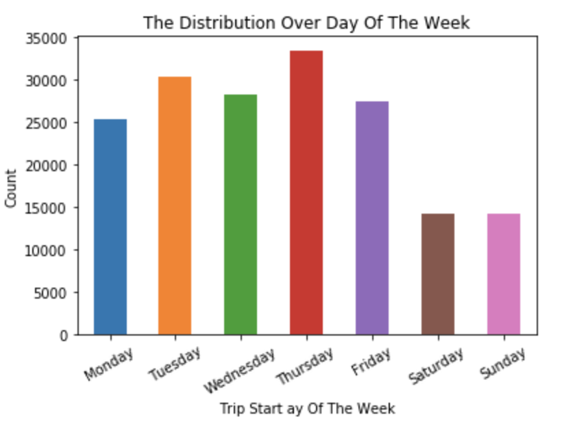

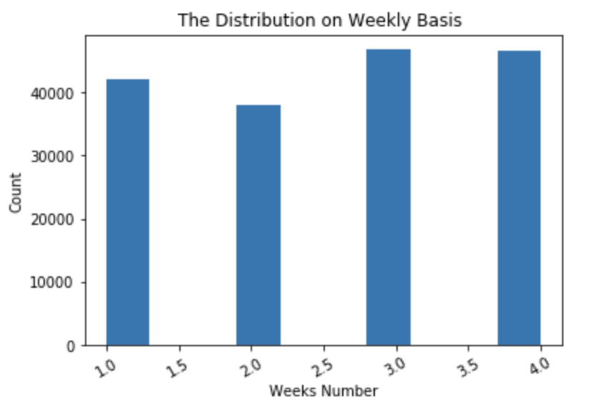

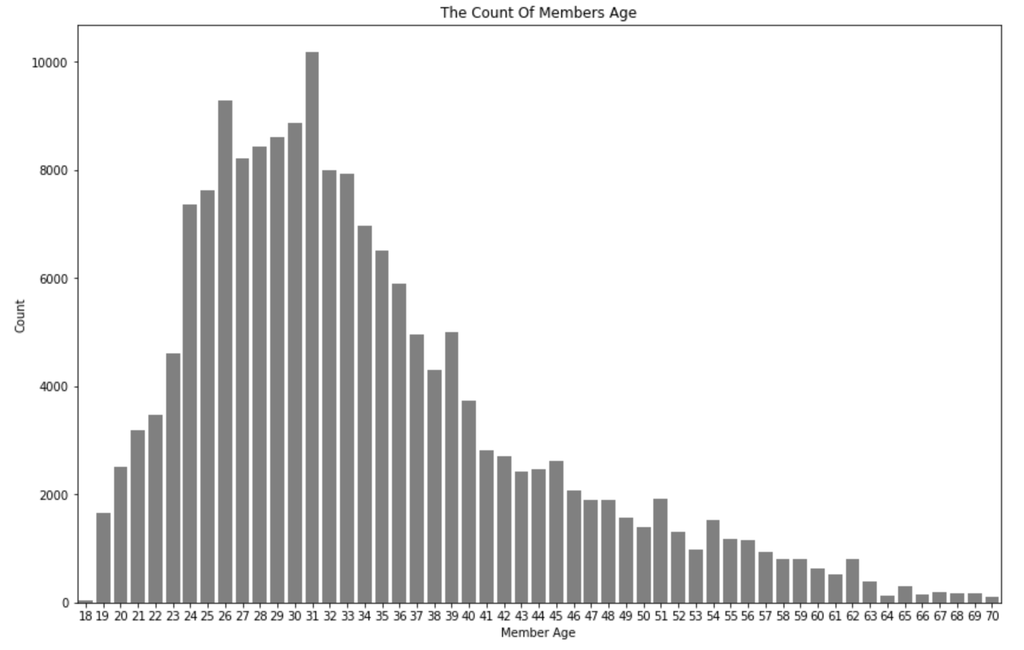

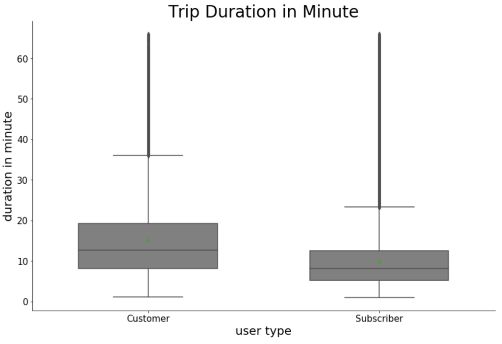

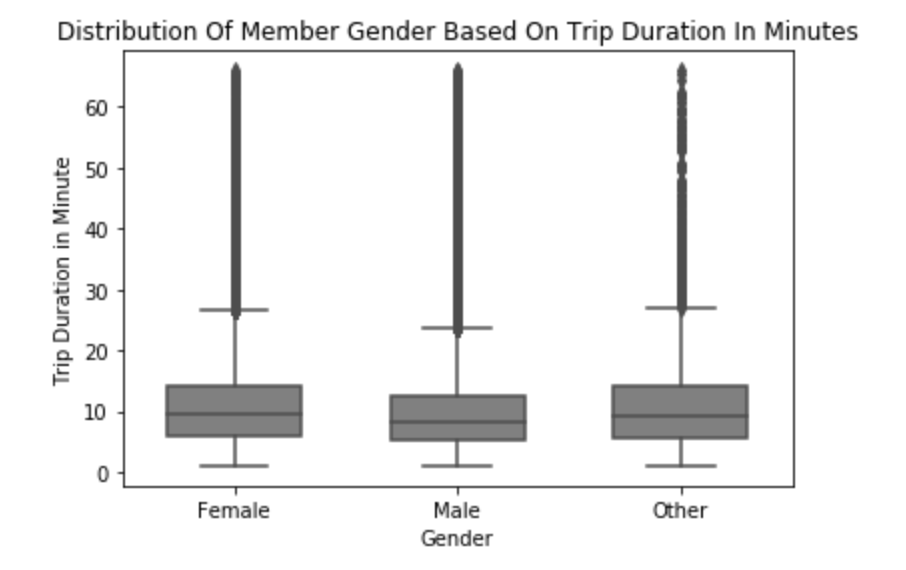

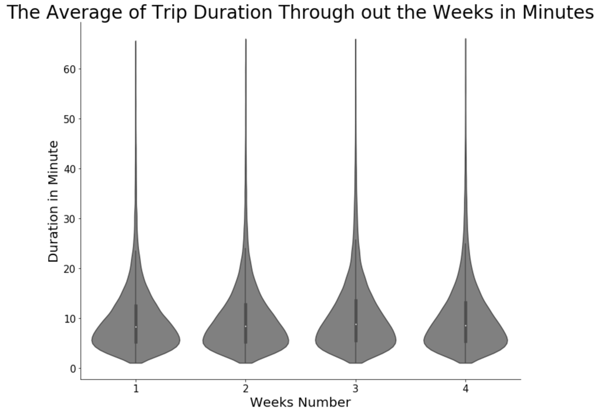

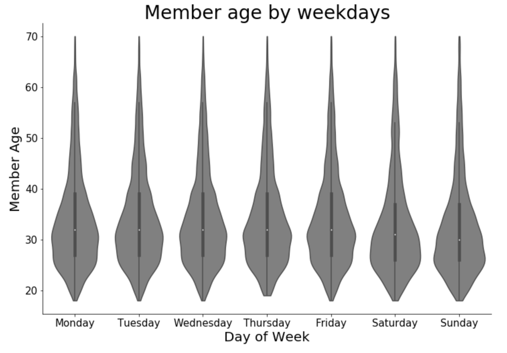

## Average Weekday Trip Duration for Customers and Subscribers

> The bellow graphic shows that on every day of the week, subscribers take shorter/quicker trips than non-subscribers. On Saturdays and Sundays, both user categories' trip lengths clearly rise compared to weekends, notably for casual riders. Monday through Friday, subscribers' usage had a fairly steady average length and appeared to be more effective than customers overall.

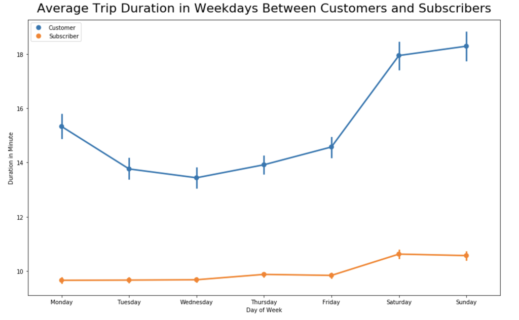

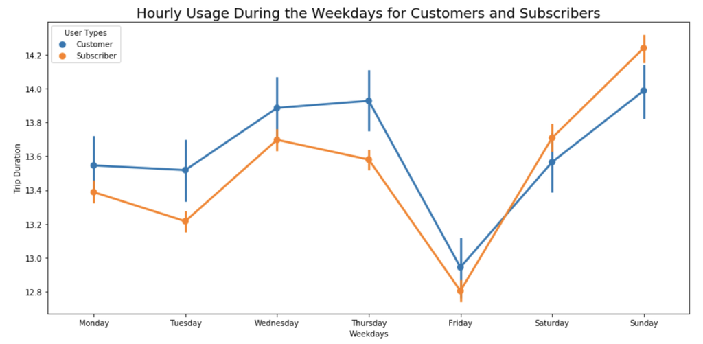

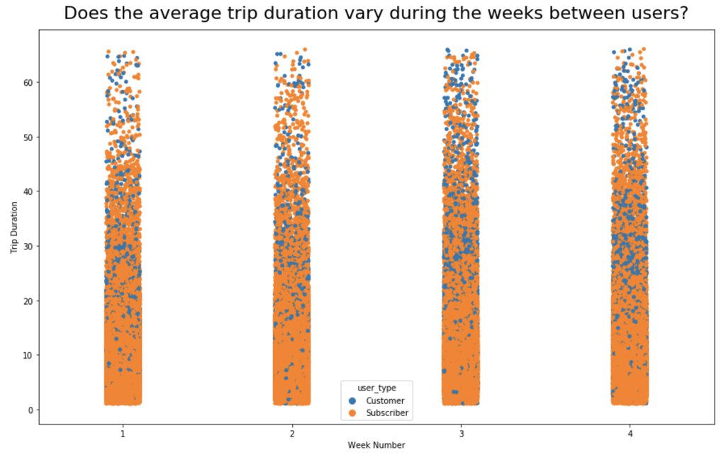

The relationship between the various variables plotted is seen collectively and information is displayed simultaneously, strengthening some of the patterns identified in the preceding bivariate investigation as well as in the univariate research. Subscribers' efficient/short periods of consumption are consistent with their high concentration during Monday through Friday rush hours, showing that the use is mostly for commuting to work. Customers clearly utilize the bike sharing system considerably differently than subscribers, frequently on weekends and in the afternoons, likely for leisure or city tours, as seen by the more flexible and relaxing pattern of their usage.